# Hypertension

#### 2.1.4.3 Statistics of the new harmonized variable

History of Hypertension

| Sample size | Missing values |
| --- | --- |
| 11050 | 13 |

Category

|  | 0 | 1 |
| --- | --- | --- |
| Frequency | 6368.00 | 4669.00 |
| Percentage | 57.63 | 42.25 |

Type of missing

|  | 991 | 992 | 993 | 994 | 995 | 996 | 997 | 998 | 999 | NA |
| --- | --- | --- | --- | --- | --- | --- | --- | --- | --- | --- |
| Frequency | 0 | 0 | 0 | 0 | 0 | 0 | 7.00 | 6.00 | 0 | 0 |
| Percentage | 0 | 0 | 0 | 0 | 0 | 0 | 0.06 | 0.05 | 0 | 0 |

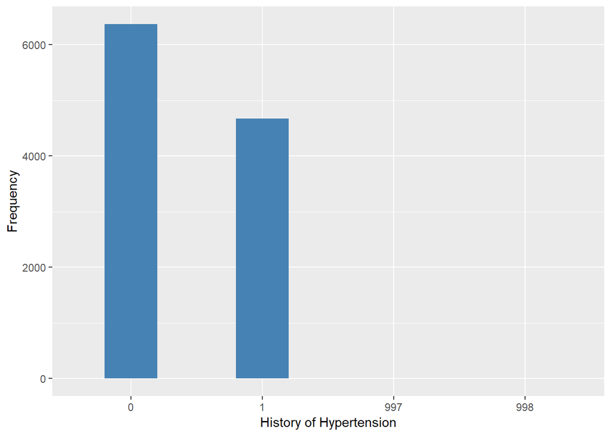

Age first diagnosed hypertension

| Sample size | Missing values |
| --- | --- |
| 11050 | 10016 |

Values

|  | No-missings | 991 | 992 | 993 | 994 | 995 | 996 | 997 | 998 | 999 | NA |
| --- | --- | --- | --- | --- | --- | --- | --- | --- | --- | --- | --- |
| Frequency | 1034.00 | 0 | 0 | 0 | 0 | 0 | 6368.00 | 0 | 0 | 3648.00 | 0 |
| Percentage | 9.36 | 0 | 0 | 0 | 0 | 0 | 57.63 | 0 | 0 | 33.01 | 0 |

Summary

| Min. | 1st Qu. | Median | Mean | 3rd Qu. | Max. |
| --- | --- | --- | --- | --- | --- |
| 40 | 57 | 65 | 65.38 | 72 | 96 |

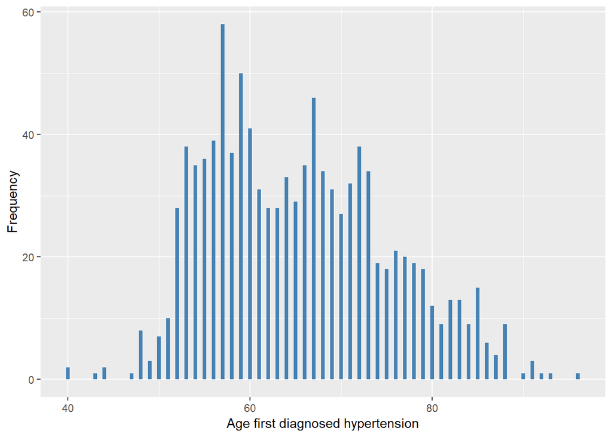

#### 2.1.4.4 Validation

|  | hedimbp==0->0 | hedimbp==1->1 | hedimbp==-9->997 | hedimbp==-8->998 |
| --- | --- | --- | --- | --- |
| BeforeH | 6368 | 4669 | 7 | 6 |
| AfterH | 6368 | 4669 | 7 | 6 |

### 2.1.5 Wave 5

#### 2.1.5.1 Study-specific variable description

| **Name** | `hedimbp` | `ybirth` | `yintw (w4)` | `yintw (w5)` |  |
| --- | --- | --- | --- | --- | --- |
| **Label** | `CVD: high blood pressure diagnosis newly reported (merged)` | `year of birth` | `year of interview` | `year of interview` |  |
| **Table name** | `wave_5_elsa_data_v4` | `elsa_w5_hd` | `elsa_w4_hd` | `elsa_w5_hd` |  |
| **Categories** | `1 = Mentioned` `0 = Not mentioned` | `continuous` | `continuous` | `continuous` |  |
| **Missings** | `-9 = Refusal` `-8 = Don't know` `-1 = Not applicable` |  |  |  |  |
| **Description** |  |  |  |  |  |

hedimbp

| Sample size | Missing values |
| --- | --- |
| 10274 | 15 |

Category

|  | 0 | 1 |
| --- | --- | --- |
| Frequency | 9483.0 | 776.00 |
| Percentage | 92.3 | 7.55 |

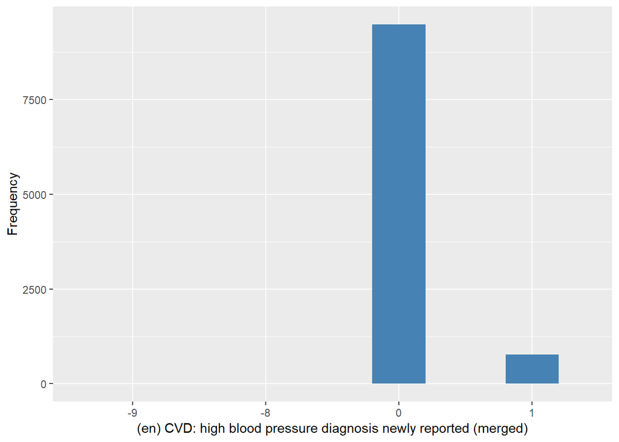

ybirth

| Sample size | Missing values |
| --- | --- |
| 10274 | 0 |

Summary

| Min. | 1st Qu. | Median | Mean | 3rd Qu. | Max. |
| --- | --- | --- | --- | --- | --- |
| 1908 | 1936 | 1945 | 1943 | 1951 | 1984 |

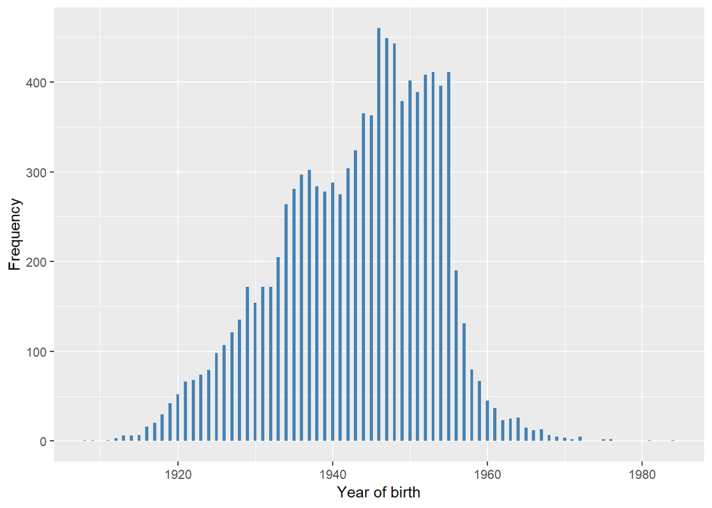

yintw (w4)

| Sample size | Missing values |
| --- | --- |
| 10274 | 814 |

Category

|  | 2008 | 2009 |
| --- | --- | --- |
| Frequency | 6181.00 | 3279.00 |
| Percentage | 60.16 | 31.92 |

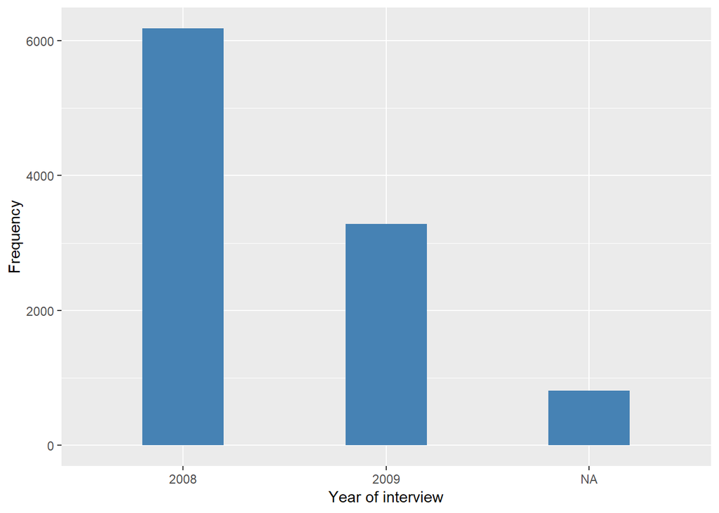

yintw (w5)

| Sample size | Missing values |
| --- | --- |
| 10274 | 0 |

Category

|  | 2010 | 2011 |
| --- | --- | --- |
| Frequency | 7066.00 | 3208.00 |
| Percentage | 68.78 | 31.22 |

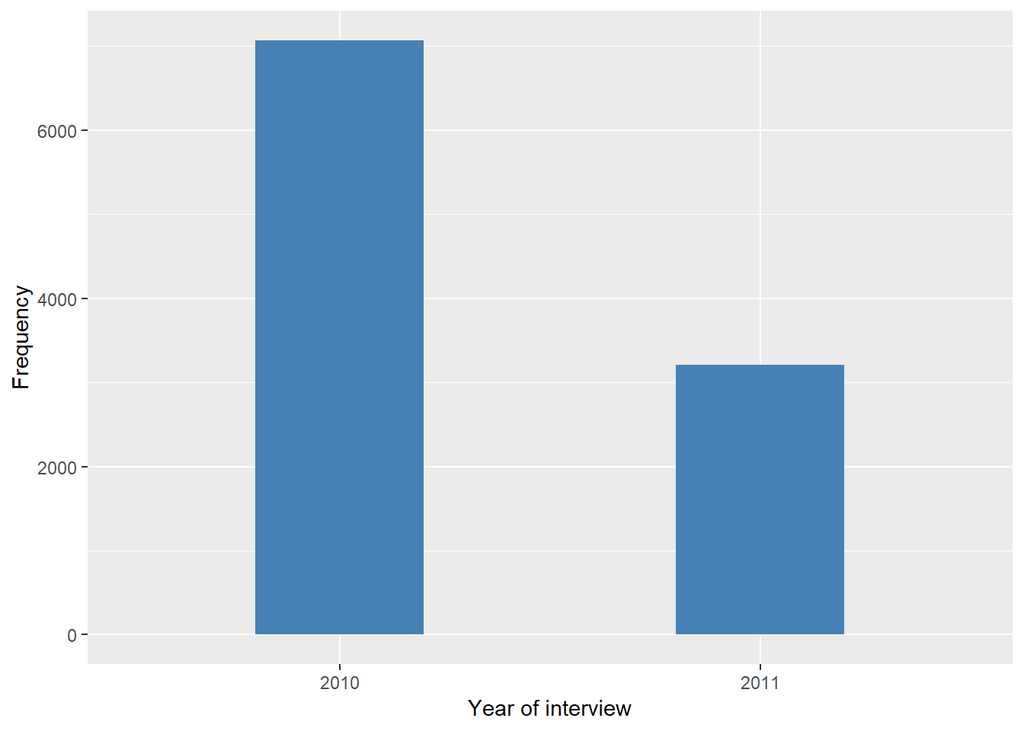

#### 2.1.5.2 Harmonisation algorithm

To compute `h_hypertension` from the study-specific variable it has to be recoded as follows:

- `h_hypertension previous == 1 or hedimbp == 1 into 1`
- `h_hypertension previous == 0 and hedimbp == 0 into 0`
- `hedimbp == -9 into 997`
- `hedimbp == -8 into 998`
- `otherwise into 999`

To compute `h_hypertension_age` from the study-specific variable it has to be recoded as follows:

- `if h_hypertension == 1 in w5 and 0 in w4, h_hypertension_age = (year of interview w5-year of interview w4)/2+(year of interview w4 - ybirth)`
- `if h_hypertension == 0, h_hypertension_age = 996`
- `otherwise, h_hypertension_age = 999`

**R script:**

```r
ELSA_w5 <- left_join(ELSA_w5, ELSA_ds, by = "id")

# Categorical variable harmonization
ELSA_ds_w5 <- tibble(id = ELSA_w5$id)
ELSA_ds_w5$h_hypertension <- rep(999, length(ELSA_w5$id))
ELSA_ds_w5$h_hypertension[which((ELSA_w5$h_hypertension != 1 | is.na(ELSA_w5$h_hypertension)) &
    (ELSA_w5$hedimbp == 0))] <- 0
ELSA_ds_w5$h_hypertension[which(ELSA_w5$h_hypertension == 1 | (ELSA_w5$hedimbp ==
    1))] <- 1
ELSA_ds_w5$h_hypertension[which((ELSA_w5$h_hypertension != 1 | is.na(ELSA_w5$h_hypertension)) &
    ELSA_w5$hedimbp == -9)] <- 997
ELSA_ds_w5$h_hypertension[which((ELSA_w5$h_hypertension != 1 | is.na(ELSA_w5$h_hypertension)) &
    ELSA_w5$hedimbp == -8)] <- 998

ELSA_w5 <- left_join(ELSA_w5, ELSA_ds_w4, by = "id", suffix = c("", "_w4"))

# Continuous variable harmonization
ELSA_ds_w5$h_hypertension_age <- rep(999, length(ELSA_w5$id))
ELSA_ds_w5$h_hypertension_age[which(ELSA_ds_w5$h_hypertension == 0)] <- 996
ELSA_ds_w5$h_hypertension_age[which(ELSA_ds_w5$h_hypertension == 1 & ELSA_w5$h_hypertension_w4 ==
    0)] <- floor((ELSA_w5$yintw_w5[which(ELSA_ds_w5$h_hypertension == 1 & ELSA_w5$h_hypertension_w4 ==
    0)] + ELSA_w5$yintw_w4[which(ELSA_ds_w5$h_hypertension == 1 & ELSA_w5$h_hypertension_w4 ==
    0)])/2 - ELSA_w5$ybirth[which(ELSA_ds_w5$h_hypertension == 1 & ELSA_w5$h_hypertension_w4 ==
    0)])
ELSA_ds_w5$h_hypertension_age[which(ELSA_ds_w5$h_hypertension == 1 & !is.na(ELSA_w5$h_hypertension_age) &
    !ELSA_w5$h_hypertension_age %in% miss_values_vector)] <- ELSA_w5$h_hypertension_age[which(ELSA_ds_w5$h_hypertension ==
    1 & !is.na(ELSA_w5$h_hypertension_age) & !ELSA_w5$h_hypertension_age %in%
    miss_values_vector)]

# Update of global table
assign_merge <- function(endtib, sttib, log_vec = c(T), col_end_index = NULL,
    col_st_index = NULL) {
    newtib <- full_join(endtib, sttib, by = "id")
    row.names(newtib) <- newtib$id
    newtib[log_vec, col_end_index] <- newtib[log_vec, col_st_index]
    id_ind <- match("id", names(newtib))
    newtib <- newtib[, c(id_ind, col_end_index)]
    names(newtib)[2] <- "x"
    newtib$x <- car::recode(newtib$x, "NA=999")
    names(newtib)[2] <- names(endtib)[col_end_index]
    newtib
}
ELSA_ds_prov <- ELSA_ds[, c(1, 2)]
ELSA_ds_prov <- assign_merge(ELSA_ds_prov, ELSA_ds_w5, log_vec = ELSA_ds_w5$id,
    col_end_index = 2, col_st_index = 3)
ELSA_ds_aux <- ELSA_ds[, c(1, 3)]
ELSA_ds_aux <- assign_merge(ELSA_ds_aux, ELSA_ds_w5, log_vec = ELSA_ds_w5$id[which(ELSA_ds_w5$h_hypertension !=
    999)], col_end_index = 2, col_st_index = 4)
ELSA_ds <- ELSA_ds_prov
ELSA_ds$h_hypertension_age <- ELSA_ds_aux$h_hypertension_age
rm(ELSA_ds_prov)
rm(ELSA_ds_aux)
```

#### 2.1.5.3 Statistics of the new harmonized variable

History of Hypertension

| Sample size | Missing values |
| --- | --- |
| 10274 | 10 |

Category

|  | 0 | 1 |
| --- | --- | --- |
| Frequency | 5544.00 | 4720.00 |
| Percentage | 53.96 | 45.94 |

Type of missing

|  | 991 | 992 | 993 | 994 | 995 | 996 | 997 | 998 | 999 | NA |
| --- | --- | --- | --- | --- | --- | --- | --- | --- | --- | --- |
| Frequency | 0 | 0 | 0 | 0 | 0 | 0 | 4.00 | 6.00 | 0 | 0 |
| Percentage | 0 | 0 | 0 | 0 | 0 | 0 | 0.04 | 0.06 | 0 | 0 |

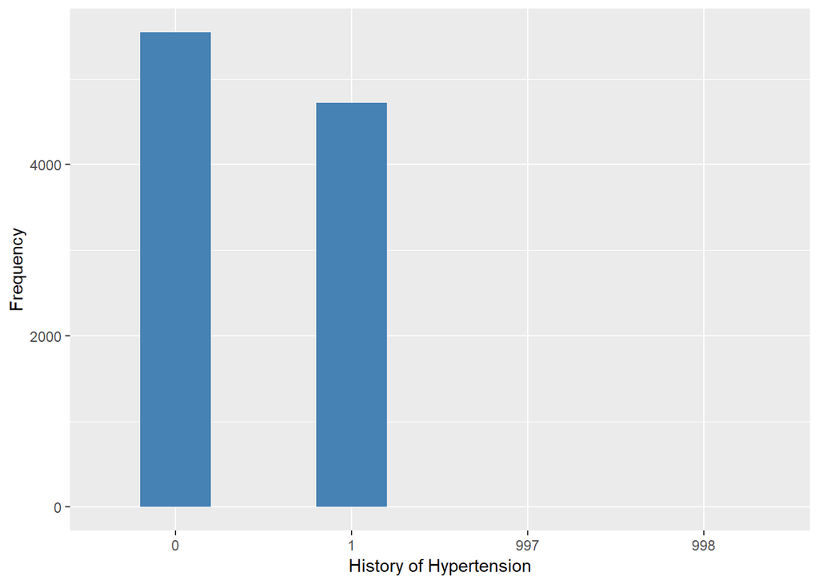

Age first diagnosed hypertension

| Sample size | Missing values |
| --- | --- |
| 10274 | 8940 |

Values

|  | No-missings | 991 | 992 | 993 | 994 | 995 | 996 | 997 | 998 | 999 | NA |
| --- | --- | --- | --- | --- | --- | --- | --- | --- | --- | --- | --- |
| Frequency | 1334.00 | 0 | 0 | 0 | 0 | 0 | 5544.00 | 0 | 0 | 3396.00 | 0 |
| Percentage | 12.98 | 0 | 0 | 0 | 0 | 0 | 53.96 | 0 | 0 | 33.05 | 0 |

Summary

| Min. | 1st Qu. | Median | Mean | 3rd Qu. | Max. |
| --- | --- | --- | --- | --- | --- |
| 40 | 57 | 64 | 64.94 | 71.75 | 93 |

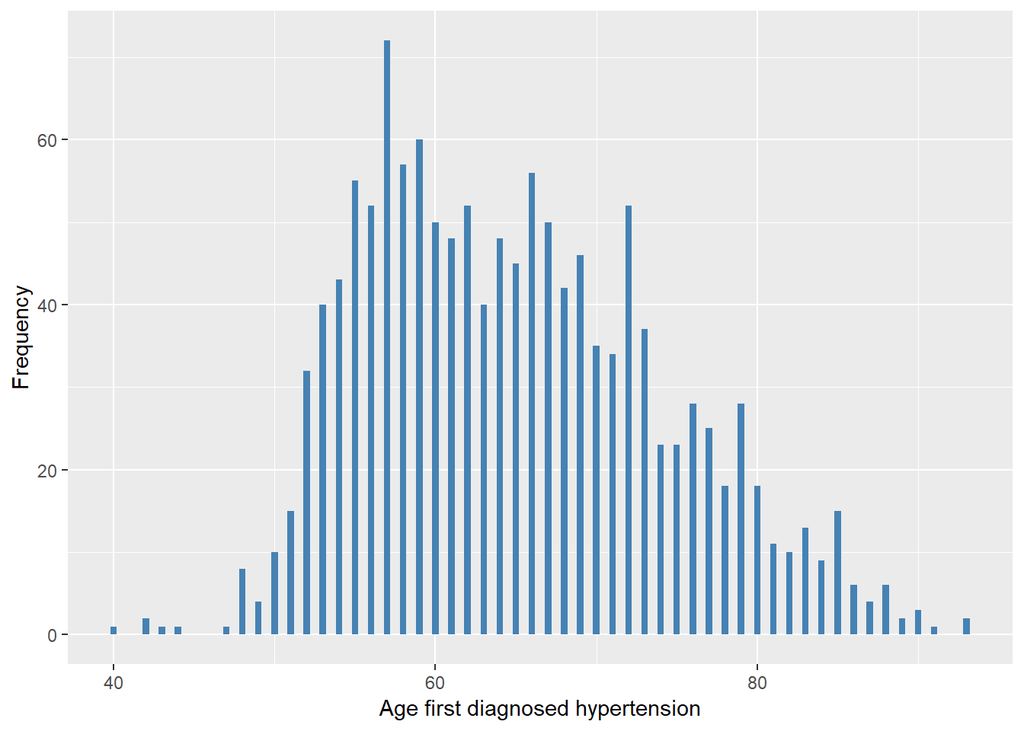

#### 2.1.5.4 Validation

|  | hedimbp==0->0 | hedimbp==1->1 | hedimbp==-9->997 | hedimbp==-8->998 |
| --- | --- | --- | --- | --- |
| BeforeH | 5544 | 4720 | 4 | 6 |
| AfterH | 5544 | 4720 | 4 | 6 |

### 2.1.6 Wave 6

#### 2.1.6.1 Study-specific variable description

| **Name** | `hedimbp` | `ybirth` | `yintw (w5)` | `yintw (w6)` |
| --- | --- | --- | --- | --- |
| **Label** | `CVD: high blood pressure diagnosis newly reported (merged)` | `year of birth` | `year of interview` | `year of interview` |
| **Table name** | `wave_6_elsa_data_v2` | `elsa_w6_hd` | `elsa_w5_hd` | `elsa_w6_hd` |
| **Categories** | `1 = Mentioned` `0 = Not mentioned` | `continuous` | `continuous` | `continuous` |
| **Missings** | `-9 = Refusal` `-8 = Don't know` `-1 = Not applicable` |  |  |  |
| **Description** |  |  |  |  |

hedimbp

| Sample size | Missing values |
| --- | --- |
| 10601 | 11 |

Category

|  | 0 | 1 |
| --- | --- | --- |
| Frequency | 9763.0 | 827.0 |
| Percentage | 92.1 | 7.8 |

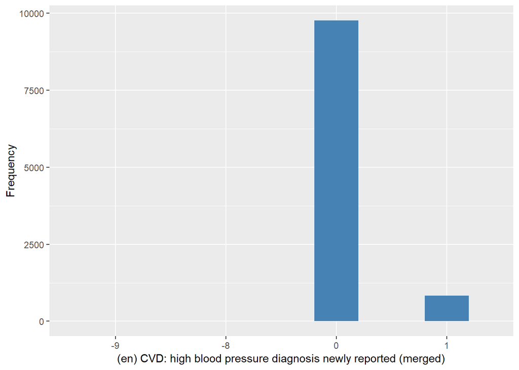

ybirth

| Sample size | Missing values |
| --- | --- |
| 10601 | 0 |

Summary

| Min. | 1st Qu. | Median | Mean | 3rd Qu. | Max. |
| --- | --- | --- | --- | --- | --- |
| 1911 | 1938 | 1946 | 1945 | 1953 | 1984 |

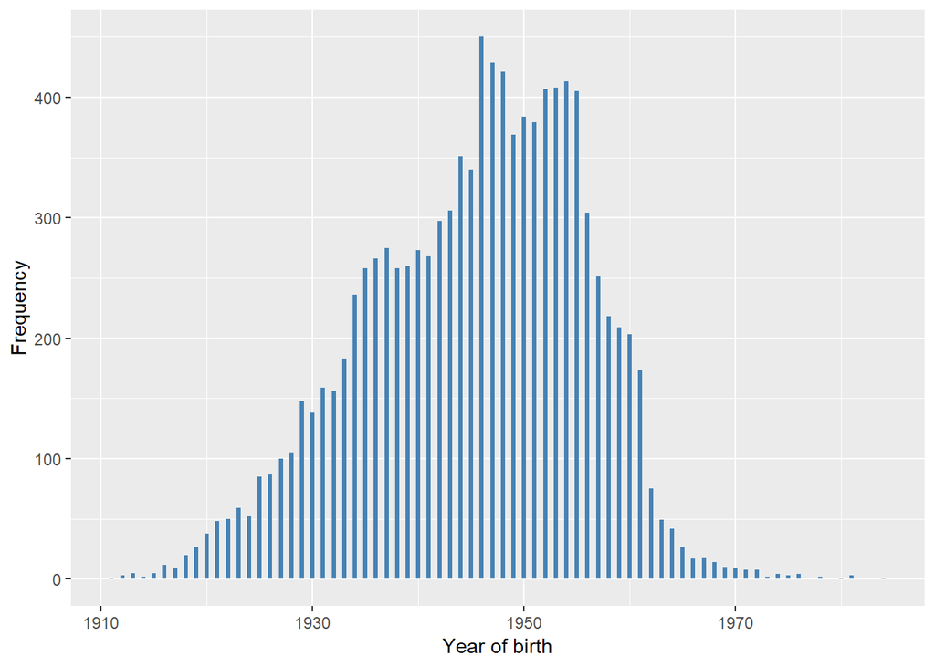

yintw (w6)

| Sample size | Missing values |
| --- | --- |
| 10601 | 0 |

Category

|  | 2012 | 2013 |
| --- | --- | --- |
| Frequency | 9047.00 | 1554.00 |
| Percentage | 85.34 | 14.66 |

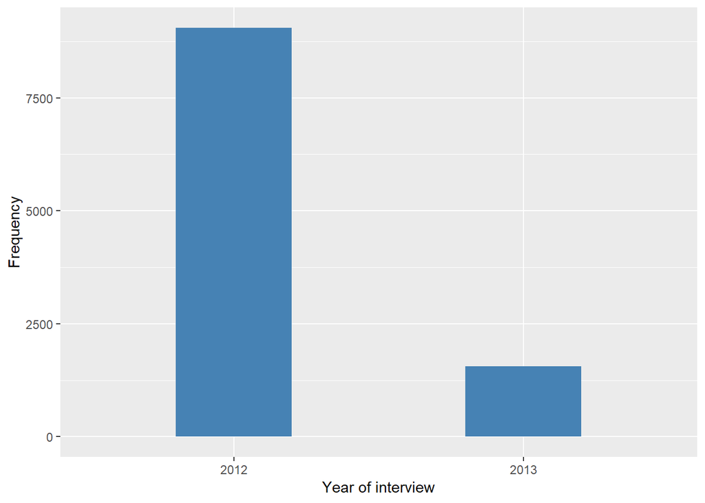

yintw (w5)

| Sample size | Missing values |
| --- | --- |
| 10601 | 1602 |

Category

|  | 2010 | 2011 |
| --- | --- | --- |
| Frequency | 6204.00 | 2795.00 |
| Percentage | 58.52 | 26.37 |

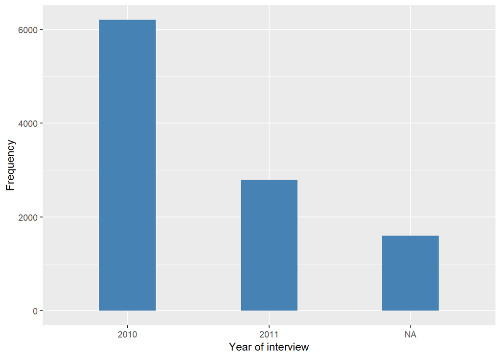

#### 2.1.6.2 Harmonisation algorithm

To compute `h_hypertension` from the study-specific variable it has to be recoded as follows:

- `h_hypertension previous == 1 or hedimbp == 1 into 1`
- `h_hypertension previous == 0 and hedimbp == 0 into 0`
- `hedimbp == -9 into 997`
- `hedimbp == -8 into 998`
- `otherwise into 999`

To compute `h_hypertension_age` from the study-specific variable it has to be recoded as follows:

- `if h_hypertension == 1 in w6 and 0 in w5, h_hypertension_age = (year of interview w6-year of interview w5)/2+(year of interview w5 - ybirth)`
- `if h_hypertension == 0, h_hypertension_age = 996`
- `otherwise, h_hypertension_age = 999`

**R script:**

```r
ELSA_w6 <- left_join(ELSA_w6, ELSA_ds, by = "id")

# Categorical variable harmonization
ELSA_ds_w6 <- tibble(id = ELSA_w6$id)
ELSA_ds_w6$h_hypertension <- rep(999, length(ELSA_w6$id))
ELSA_ds_w6$h_hypertension[which((ELSA_w6$h_hypertension != 1 | is.na(ELSA_w6$h_hypertension)) &
    (ELSA_w6$hedimbp == 0))] <- 0
ELSA_ds_w6$h_hypertension[which(ELSA_w6$h_hypertension == 1 | (ELSA_w6$hedimbp ==
    1))] <- 1
ELSA_ds_w6$h_hypertension[which((ELSA_w6$h_hypertension != 1 | is.na(ELSA_w6$h_hypertension)) &
    ELSA_w6$hedimbp == -9)] <- 997
ELSA_ds_w6$h_hypertension[which((ELSA_w6$h_hypertension != 1 | is.na(ELSA_w6$h_hypertension)) &
    ELSA_w6$hedimbp == -8)] <- 998

ELSA_w6 <- left_join(ELSA_w6, ELSA_ds_w5, by = "id", suffix = c("", "_w5"))

# Continuous variable harmonization
ELSA_ds_w6$h_hypertension_age <- rep(999, length(ELSA_w6$id))
ELSA_ds_w6$h_hypertension_age[which(ELSA_ds_w6$h_hypertension == 0)] <- 996
ELSA_ds_w6$h_hypertension_age[which(ELSA_ds_w6$h_hypertension == 1 & ELSA_w6$h_hypertension_w5 ==
    0)] <- floor((ELSA_w6$yintw_w5[which(ELSA_ds_w6$h_hypertension == 1 & ELSA_w6$h_hypertension_w5 ==
    0)] + ELSA_w6$yintw_w6[which(ELSA_ds_w6$h_hypertension == 1 & ELSA_w6$h_hypertension_w5 ==
    0)])/2 - ELSA_w6$ybirth[which(ELSA_ds_w6$h_hypertension == 1 & ELSA_w6$h_hypertension_w5 ==
    0)])
ELSA_ds_w6$h_hypertension_age[which(ELSA_ds_w6$h_hypertension == 1 & !is.na(ELSA_w6$h_hypertension_age) &
    !ELSA_w6$h_hypertension_age %in% miss_values_vector)] <- ELSA_w6$h_hypertension_age[which(ELSA_ds_w6$h_hypertension ==
    1 & !is.na(ELSA_w6$h_hypertension_age) & !ELSA_w6$h_hypertension_age %in%
    miss_values_vector)]

# Update of global table
assign_merge <- function(endtib, sttib, log_vec = c(T), col_end_index = NULL,
    col_st_index = NULL) {
    newtib <- full_join(endtib, sttib, by = "id")
    row.names(newtib) <- newtib$id
    newtib[log_vec, col_end_index] <- newtib[log_vec, col_st_index]
    id_ind <- match("id", names(newtib))
    newtib <- newtib[, c(id_ind, col_end_index)]
    names(newtib)[2] <- "x"
    newtib$x <- car::recode(newtib$x, "NA=999")
    names(newtib)[2] <- names(endtib)[col_end_index]
    newtib
}
ELSA_ds_prov <- ELSA_ds[, c(1, 2)]
ELSA_ds_prov <- assign_merge(ELSA_ds_prov, ELSA_ds_w6, log_vec = ELSA_ds_w6$id,
    col_end_index = 2, col_st_index = 3)
ELSA_ds_aux <- ELSA_ds[, c(1, 3)]
ELSA_ds_aux <- assign_merge(ELSA_ds_aux, ELSA_ds_w6, log_vec = ELSA_ds_w6$id[which(ELSA_ds_w6$h_hypertension !=
    999)], col_end_index = 2, col_st_index = 4)
ELSA_ds <- ELSA_ds_prov
ELSA_ds$h_hypertension_age <- ELSA_ds_aux$h_hypertension_age
rm(ELSA_ds_prov)
rm(ELSA_ds_aux)
```

#### 2.1.6.3 Statistics of the new harmonized variable

History of Hypertension

| Sample size | Missing values |
| --- | --- |
| 10601 | 8 |

Category

|  | 0 | 1 |
| --- | --- | --- |
| Frequency | 5802.00 | 4791.00 |
| Percentage | 54.73 | 45.19 |

Type of missing

|  | 991 | 992 | 993 | 994 | 995 | 996 | 997 | 998 | 999 | NA |
| --- | --- | --- | --- | --- | --- | --- | --- | --- | --- | --- |
| Frequency | 0 | 0 | 0 | 0 | 0 | 0 | 4.00 | 4.00 | 0 | 0 |
| Percentage | 0 | 0 | 0 | 0 | 0 | 0 | 0.04 | 0.04 | 0 | 0 |

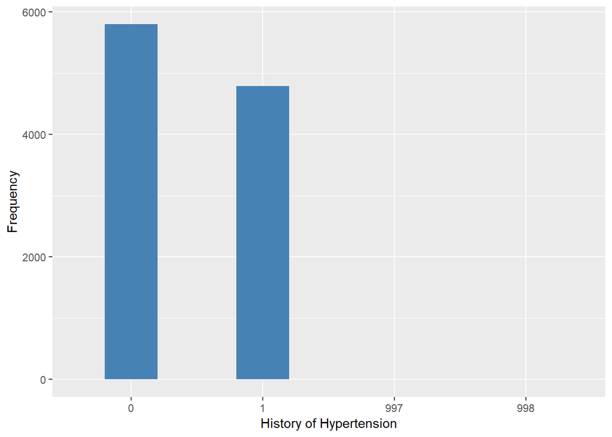

Age first diagnosed hypertension

| Sample size | Missing values |
| --- | --- |
| 10601 | 9154 |

Values

|  | No-missings | 991 | 992 | 993 | 994 | 995 | 996 | 997 | 998 | 999 | NA |
| --- | --- | --- | --- | --- | --- | --- | --- | --- | --- | --- | --- |
| Frequency | 1447.00 | 0 | 0 | 0 | 0 | 0 | 5802.00 | 0 | 0 | 3352.00 | 0 |
| Percentage | 13.65 | 0 | 0 | 0 | 0 | 0 | 54.73 | 0 | 0 | 31.62 | 0 |

Summary

| Min. | 1st Qu. | Median | Mean | 3rd Qu. | Max. |
| --- | --- | --- | --- | --- | --- |
| 40 | 58 | 64 | 64.88 | 71 | 93 |

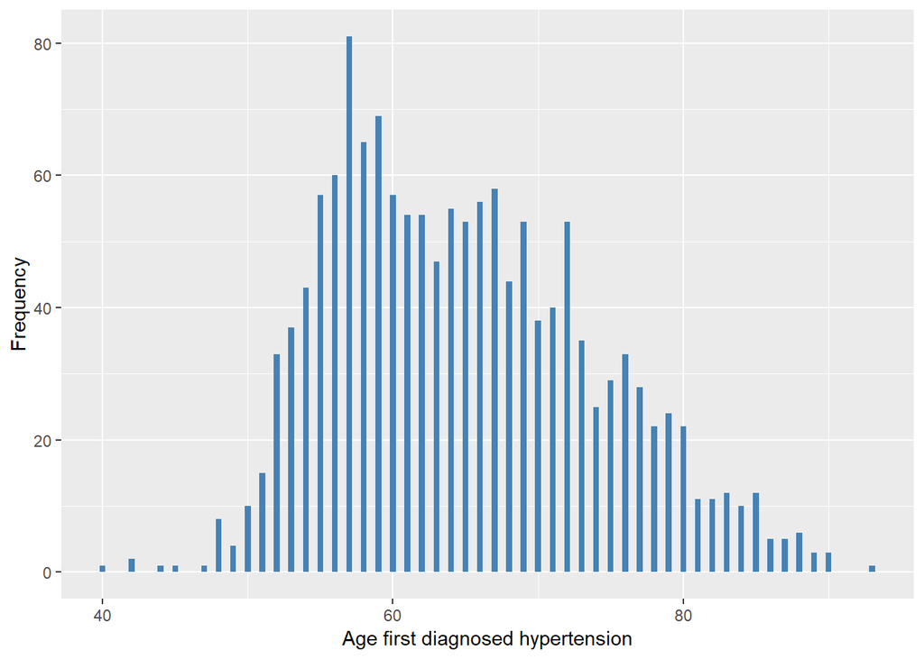

#### 2.1.6.4 Validation

|  | hedimbp==0->0 | hedimbp==1->1 | hedimbp==-9->997 | hedimbp==-8->998 |
| --- | --- | --- | --- | --- |
| BeforeH | 5802 | 4791 | 4 | 4 |
| AfterH | 5802 | 4791 | 4 | 4 |

### 2.1.7 Wave 7

#### 2.1.7.1 Study-specific variable description

[output not shown]

hedimbp

| Sample size | Missing values |
| --- | --- |
| 9666 | 6 |

Category

|  | 0 | 1 |
| --- | --- | --- |
| Frequency | 9006.00 | 654.00 |
| Percentage | 93.17 | 6.77 |

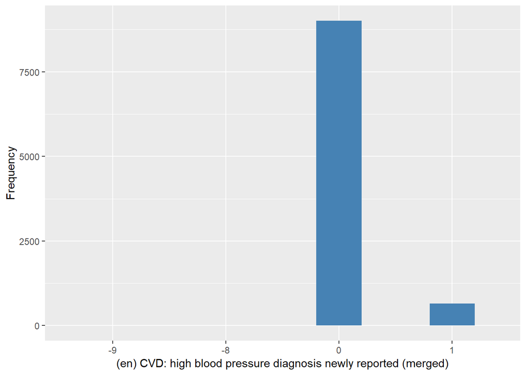

ybirth

| Sample size | Missing values |
| --- | --- |
| 9666 | 0 |

Summary

| Min. | 1st Qu. | Median | Mean | 3rd Qu. | Max. |
| --- | --- | --- | --- | --- | --- |
| 1911 | 1939 | 1947 | 1946 | 1954 | 1985 |

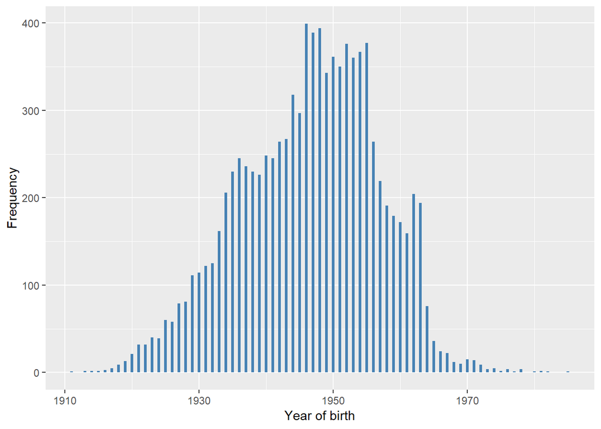

yintw (w6)

| Sample size | Missing values |
| --- | --- |
| 9666 | 800 |

Category

|  | 2012 | 2013 |
| --- | --- | --- |
| Frequency | 7623.00 | 1243.00 |
| Percentage | 78.86 | 12.86 |

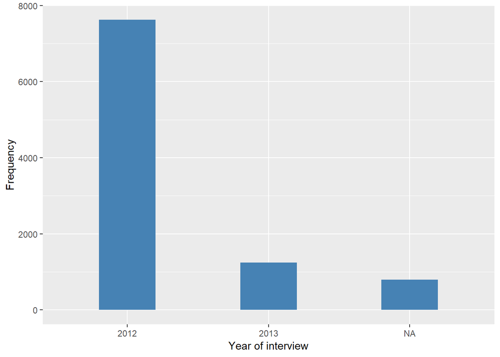

yintw (w7)

| Sample size | Missing values |
| --- | --- |
| 9666 | 0 |

Category

|  | 2014 | 2015 |
| --- | --- | --- |
| Frequency | 7695.00 | 1971.00 |
| Percentage | 79.61 | 20.39 |

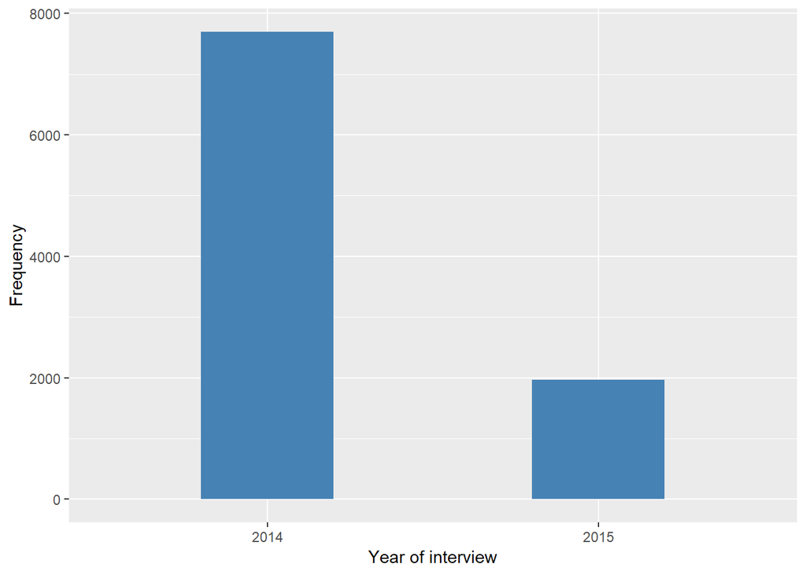

#### 2.1.7.2 Harmonisation algorithm

To compute `h_hypertension` from the study-specific variable it has to be recoded as follows:

- `h_hypertension previous == 1 or hedimbp == 1 into 1`
- `h_hypertension previous == 0 and hedimbp == 0 into 0`
- `h_hypertension previous == 0 and hedimbp == -9 into 997`
- `h_hypertension previous == 0 and hedimbp == -8 into 998`
- `otherwise into 999`

To compute `h_hypertension_age` from the study-specific variable it has to be recoded as follows:

- `if h_hypertension == 1 in w7 and 0 in w6, h_hypertension_age = (year of interview w7-year of interview w6)/2+(year of interview w6 - ybirth)`
- `if h_hypertension == 0, h_hypertension_age = 996`
- `otherwise, h_hypertension_age = 999`

**R script:**

```r
ELSA_w7 <- left_join(ELSA_w7, ELSA_ds, by = "id")

# Categorical variable harmonization
ELSA_ds_w7 <- tibble(id = ELSA_w7$id)
ELSA_ds_w7$h_hypertension <- rep(999, length(ELSA_w7$id))
ELSA_ds_w7$h_hypertension[which((ELSA_w7$h_hypertension != 1 | is.na(ELSA_w7$h_hypertension)) &
    (ELSA_w7$hedimbp == 0))] <- 0
ELSA_ds_w7$h_hypertension[which(ELSA_w7$h_hypertension == 1 | ELSA_w7$hedimbp ==
    1)] <- 1
ELSA_ds_w7$h_hypertension[which((ELSA_w7$h_hypertension != 1 | is.na(ELSA_w7$h_hypertension)) &
    ELSA_w7$hedimbp == -9)] <- 997
ELSA_ds_w7$h_hypertension[which((ELSA_w7$h_hypertension != 1 | is.na(ELSA_w7$h_hypertension)) &
    ELSA_w7$hedimbp == -8)] <- 998

ELSA_w7 <- left_join(ELSA_w7, ELSA_ds_w6, by = "id", suffix = c("", "_w6"))

# Continuous variable harmonization
ELSA_ds_w7$h_hypertension_age <- rep(999, length(ELSA_w7$id))
ELSA_ds_w7$h_hypertension_age[which(ELSA_ds_w7$h_hypertension == 0)] <- 996
ELSA_ds_w7$h_hypertension_age[which(ELSA_ds_w7$h_hypertension == 1 & ELSA_w7$h_hypertension_w6 ==
    0)] <- floor((ELSA_w7$yintw_w6[which(ELSA_ds_w7$h_hypertension == 1 & ELSA_w7$h_hypertension_w6 ==
    0)] + ELSA_w7$yintw_w7[which(ELSA_ds_w7$h_hypertension == 1 & ELSA_w7$h_hypertension_w6 ==
    0)])/2 - ELSA_w7$ybirth[which(ELSA_ds_w7$h_hypertension == 1 & ELSA_w7$h_hypertension_w6 ==
    0)])
ELSA_ds_w7$h_hypertension_age[which(ELSA_ds_w7$h_hypertension == 1 & !is.na(ELSA_w7$h_hypertension_age) &
    !ELSA_w7$h_hypertension_age %in% miss_values_vector)] <- ELSA_w7$h_hypertension_age[which(ELSA_ds_w7$h_hypertension ==
    1 & !is.na(ELSA_w7$h_hypertension_age) & !ELSA_w7$h_hypertension_age %in%
    miss_values_vector)]


# Update of global table
rm(ELSA_ds)
```

#### 2.1.7.3 Statistics of the new harmonized variable

History of Hypertension

| Sample size | Missing values |
| --- | --- |
| 9666 | 3 |

Category

|  | 0 | 1 |
| --- | --- | --- |
| Frequency | 5224.00 | 4439.00 |
| Percentage | 54.05 | 45.92 |

Type of missing

|  | 991 | 992 | 993 | 994 | 995 | 996 | 997 | 998 | 999 | NA |
| --- | --- | --- | --- | --- | --- | --- | --- | --- | --- | --- |
| Frequency | 0 | 0 | 0 | 0 | 0 | 0 | 1.00 | 2.00 | 0 | 0 |
| Percentage | 0 | 0 | 0 | 0 | 0 | 0 | 0.01 | 0.02 | 0 | 0 |

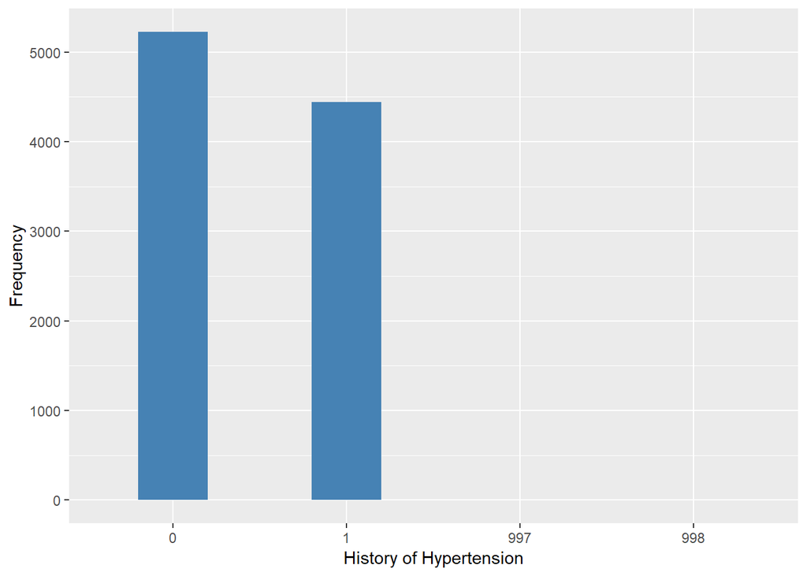

Age first diagnosed hypertension

| Sample size | Missing values |
| --- | --- |
| 9666 | 8118 |

Values

|  | No-missings | 991 | 992 | 993 | 994 | 995 | 996 | 997 | 998 | 999 | NA |
| --- | --- | --- | --- | --- | --- | --- | --- | --- | --- | --- | --- |
| Frequency | 1548.00 | 0 | 0 | 0 | 0 | 0 | 5224.00 | 0 | 0 | 2894.00 | 0 |
| Percentage | 16.01 | 0 | 0 | 0 | 0 | 0 | 54.05 | 0 | 0 | 29.94 | 0 |

Summary

| Min. | 1st Qu. | Median | Mean | 3rd Qu. | Max. |
| --- | --- | --- | --- | --- | --- |
| 40 | 58 | 64 | 64.99 | 71 | 95 |

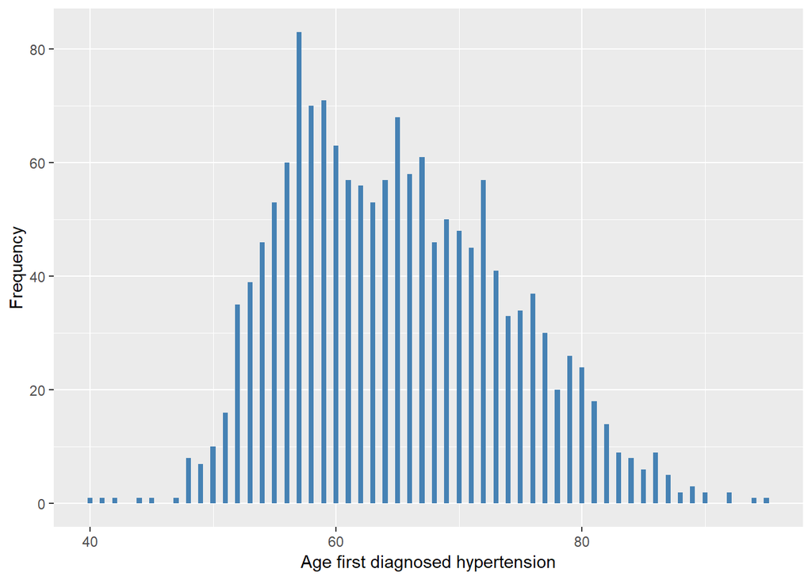

#### 2.1.7.4 Validation

|  | hedimbp==0->0 | hedimbp==1->1 | hedimbp==-9->997 | hedimbp==-8->998 |
| --- | --- | --- | --- | --- |
| BeforeH | 5224 | 4439 | 1 | 2 |
| AfterH | 5224 | 4439 | 1 | 2 |

## 2.2 Descriptive statistics of the harmonised variable `h_hypertension` accross populations and waves

Two tables are generated:

1. Percentages of categories in each harmonised variable.
2. Frequencies and percentages of individuals with different trajectories. To avoid too large table, Only trajectories with percentages larger than 0.3 are shown.

History of Hypertension

| val | label | W1 | W2 | W3 | W4 | W5 | W6 | W7 |
| --- | --- | --- | --- | --- | --- | --- | --- | --- |
| 0 | No | 62.95 | 56.82 | 56.91 | 57.63 | 53.96 | 54.73 | 54.05 |
| 1 | Yes | 36.98 | 43.14 | 43.08 | 42.25 | 45.94 | 45.19 | 45.92 |
| 991 | CAPI interviewer error | 0 | 0 | 0 | 0 | 0 | 0 | 0 |
| 992 | Impute | 0 | 0 | 0 | 0 | 0 | 0 | 0 |
| 993 | Disable to measure | 0 | 0 | 0 | 0 | 0 | 0 | 0 |
| 994 | Not attempt not done | 0 | 0 | 0 | 0 | 0 | 0 | 0 |
| 995 | Does not answer | 0 | 0 | 0 | 0 | 0 | 0 | 0 |
| 996 | Not applicable | 0 | 0 | 0.01 | 0 | 0 | 0 | 0 |
| 997 | Refuse | 0.02 | 0.01 | 0 | 0.06 | 0.04 | 0.04 | 0.01 |
| 998 | Do not know | 0.05 | 0.03 | 0 | 0.05 | 0.06 | 0.04 | 0.02 |
| 999 | Missing | 0 | 0 | 0 | 0 | 0 | 0 | 0 |
| NA | NA | 0 | 0 | 0 | 0 | 0 | 0 | 0 |
| n | sample size | 12099 | 9432 | 9771 | 11050 | 10274 | 10601 | 9666 |

|  | val | frq | raw.prc |
| --- | --- | --- | --- |
| 1 | 0000000 | 1957 | 10.58 |
| 2 | 0000001 | 113 | 0.61 |
| 3 | 000000NA | 264 | 1.43 |
| 4 | 0000011 | 99 | 0.54 |
| 8 | 00000NANA | 187 | 1.01 |
| 9 | 0000111 | 149 | 0.81 |
| 19 | 0000NANANA | 266 | 1.44 |
| 20 | 0001111 | 160 | 0.87 |
| 26 | 000NA000 | 64 | 0.35 |
| 42 | 000NANANANA | 442 | 2.39 |
| 43 | 0011111 | 206 | 1.11 |
| 91 | 00NANANANANA | 686 | 3.71 |
| 92 | 0111111 | 262 | 1.42 |
| 107 | 011NANANANA | 59 | 0.32 |
| 118 | 01NANANANANA | 98 | 0.53 |
| 143 | 0NA0NANANANA | 73 | 0.39 |
| 188 | 0NANANANANANA | 1277 | 6.91 |
| 189 | 1111111 | 1429 | 7.73 |
| 190 | 111111NA | 290 | 1.57 |
| 192 | 11111NANA | 217 | 1.17 |
| 196 | 1111NANANA | 255 | 1.38 |
| 204 | 111NANANANA | 397 | 2.15 |
| 220 | 11NANANANANA | 505 | 2.73 |
| 247 | 1NANANANANANA | 804 | 4.35 |
| 283 | NANA00000 | 538 | 2.91 |
| 285 | NANA0000NA | 70 | 0.38 |
| 290 | NANA000NANA | 57 | 0.31 |
| 300 | NANA00NANANA | 86 | 0.47 |
| 323 | NANA0NANANANA | 231 | 1.25 |
| 324 | NANA11111 | 215 | 1.16 |
| 338 | NANA1NANANANA | 76 | 0.41 |
| 339 | NANANA0000 | 1014 | 5.48 |
| 340 | NANANA0001 | 66 | 0.36 |
| 341 | NANANA000NA | 144 | 0.78 |
| 342 | NANANA0011 | 64 | 0.35 |
| 346 | NANANA00NANA | 108 | 0.58 |
| 347 | NANANA0111 | 121 | 0.65 |
| 358 | NANANA0NANANA | 244 | 1.32 |
| 359 | NANANA1111 | 440 | 2.38 |
| 360 | NANANA111NA | 90 | 0.49 |
| 362 | NANANA11NANA | 64 | 0.35 |
| 366 | NANANA1NANANA | 117 | 0.63 |
| 378 | NANANANANA00 | 671 | 3.63 |
| 380 | NANANANANA0NA | 200 | 1.08 |
| 381 | NANANANANA11 | 236 | 1.28 |
| 382 | NANANANANA1NA | 67 | 0.36 |
| 383 | NANANANANANA0 | 414 | 2.24 |
| 384 | NANANANANANA1 | 96 | 0.52 |

## 2.3 Summary of descriptive statistics of the harmonised variable `h_hypertension_age` accross populations and waves

Age first diagnosed hypertension

[output not shown]

# 3 Quality estimation

- We assume that if an individual answers it has hypertension in one wave, it has for all the next waves.